# Ford GoBike System Data Exploration

## by Dirk Henrichmoeller

```python
# import all packages and set plots to be embedded inline
import numpy as np
import pandas as pd
import matplotlib.pyplot as plt
import seaborn as sb

%matplotlib inline
# set constant global figure size
plt.rcParams['figure.figsize'] = [15, 10]
```

```python
# Helper Functions
def create_ordered_bar_chart(df, qualitative_var_as_string, y_label, percent_label_offset):
    n_points = df.shape[0]
    max_count = df[qualitative_var_as_string].value_counts().max()
    max_prop = max_count / n_points

    # generate tick mark locations and names
    tick_props = np.arange(0, max_prop, 0.05)
    tick_names = ['{:0.2f}'.format(v) for v in tick_props]

    # create the plot
    base_color = sb.color_palette()[0]
    var_order = df[qualitative_var_as_string].value_counts().index
    sb.countplot(data = df, x = qualitative_var_as_string, color = base_color, order = var_order[0:20])
    #plt.yticks(tick_props * n_points, tick_names) # comment for absolute occurances on y-axes
    plt.ylabel(y_label)

    var_counts = df[qualitative_var_as_string].value_counts()
    locs, labels = plt.xticks() # get the current tick locations and labels

    # loop through each pair of locations and labels
    for loc, label in zip(locs, labels):

        # get the text property for the label to get the correct count
        count = var_counts[label.get_text()]
        pct_string = '{:0.1f}%'.format(100 * count / n_points)

        # print the annotation just below the top of the bar
        plt.text(loc, count - percent_label_offset, pct_string, ha = 'center', color = 'black')

def freq_poly(x, bins = 10, **kwargs): # set bin edges if none or int specified
    if type(bins) == int:
        bins = np.linspace(x.min(), x.max(), bins+1)
    bin_centers = (bin_edges[1:] + bin_edges[:-1]) / 2# compute counts
    data_bins = pd.cut(x, bins, right = False,
                       include_lowest = True)
    counts = x.groupby(data_bins).count()

    # create plot
    plt.errorbar(x = bin_centers, y = counts, **kwargs)
```

## Preliminary Wrangling

The data set can be downloaded [here](https://www.lyft.com/bikes/bay-wheels/system-data). The individual channels contain the following 16 data columns:

- Trip Duration (seconds)
- Start Time and Date
- End Time and Date
- Start Station ID
- Start Station Name
- Start Station Latitude
- Start Station Longitude
- End Station ID
- End Station Name
- End Station Latitude
- End Station Longitude
- Bike ID
- User Type (Subscriber or Customer – “Subscriber” = Member or “Customer” = Casual)
- Member Year of Birth
- Member Gender

Since the data comes with one csv-file per month, 12 individual csv-files were downloaded and concatenated (after the structures similarity was validated).

```python
df_01 = pd.read_csv('201801-fordgobike-tripdata.csv')
print(df_01.shape)
df_02 = pd.read_csv('201802-fordgobike-tripdata.csv')
print(df_02.shape)
print((df_01.columns == df_02.columns).all())
df_03 = pd.read_csv('201803-fordgobike-tripdata.csv')
print(df_03.shape)
print((df_01.columns == df_03.columns).all())
df_04 = pd.read_csv('201804-fordgobike-tripdata.csv')
print(df_04.shape)
print((df_01.columns == df_04.columns).all())
df_05 = pd.read_csv('201805-fordgobike-tripdata.csv')
print(df_05.shape)
print((df_01.columns == df_05.columns).all())
df_06 = pd.read_csv('201806-fordgobike-tripdata.csv')
print(df_06.shape)
print((df_01.columns == df_06.columns).all())
df_07 = pd.read_csv('201807-fordgobike-tripdata.csv')
print(df_07.shape)
print((df_01.columns == df_07.columns).all())
df_08 = pd.read_csv('201808-fordgobike-tripdata.csv')
print(df_08.shape)
print((df_01.columns == df_08.columns).all())
df_09 = pd.read_csv('201809-fordgobike-tripdata.csv')
print(df_09.shape)
print((df_01.columns == df_09.columns).all())
df_10 = pd.read_csv('201810-fordgobike-tripdata.csv')
print(df_10.shape)
print((df_01.columns == df_10.columns).all())
df_11 = pd.read_csv('201811-fordgobike-tripdata.csv')
print(df_11.shape)
print((df_01.columns == df_11.columns).all())
df_12 = pd.read_csv('201812-fordgobike-tripdata.csv')
print(df_12.shape)
print((df_01.columns == df_12.columns).all())

df = pd.concat([df_01, df_02, df_03, df_04, df_05, df_06, df_07, df_08, df_09, df_10, df_11, df_12], ignore_index=True)
```

```
(94802, 16)
(106718, 16)
True
(111382, 16)
True
(131169, 16)
True
(179125, 16)
True
(195968, 16)
True
(199222, 16)
True
(192162, 16)
True
(186217, 16)
True
(201458, 16)
True
(134135, 16)
True
(131363, 16)
True
```

```python
# Wrangling and Cleaning

plt.rcParams['figure.figsize'] = [15, 10]
#convert time containing values to datetime type
df['start_time'] = pd.to_datetime(df['start_time'])
df['end_time'] = pd.to_datetime(df['end_time'])
#create further columns which include different date interpretations
df['start_day_of_week'] = df['start_time'].dt.weekday_name
df['start_hour_of_day'] = df['start_time'].dt.hour
df['start_month_of_year'] = df['start_time'].dt.month
df['end_day_of_week'] = df['end_time'].dt.weekday_name
df['end_hour_of_day'] = df['end_time'].dt.hour

#delete unnecessary columns
df.drop(['start_station_latitude'], axis=1, inplace=True)
df.drop(['start_station_longitude'], axis=1, inplace=True)
df.drop(['end_station_latitude'], axis=1, inplace=True)
df.drop(['end_station_longitude'], axis=1, inplace=True)
df.drop(['start_station_id'], axis=1, inplace=True)
df.drop(['end_station_id'], axis=1, inplace=True)
df.drop(['bike_share_for_all_trip'], axis=1, inplace=True)

#delete rows containing "NaN" values
df.dropna(inplace=True);
```

```python
# high-level overview of data shape and composition
print(df.shape)
print(df.dtypes)
print(df.describe())
df.head(10)
```

```
(1741556, 14)
duration_sec                    int64
start_time             datetime64[ns]
end_time               datetime64[ns]
start_station_name             object
end_station_name               object
bike_id                         int64
user_type                      object
member_birth_year             float64
member_gender                  object
start_day_of_week              object
start_hour_of_day               int64
start_month_of_year             int64
end_day_of_week                object
end_hour_of_day                 int64
dtype: object
       duration_sec       bike_id  member_birth_year  start_hour_of_day  \
count  1.741556e+06  1.741556e+06       1.741556e+06       1.741556e+06
mean   7.728624e+02  2.292758e+03       1.983061e+03       1.348719e+01
std    1.943048e+03  1.287598e+03       1.045133e+01       4.762131e+00
min    6.100000e+01  1.100000e+01       1.881000e+03       0.000000e+00
25%    3.440000e+02  1.221000e+03       1.978000e+03       9.000000e+00
50%    5.430000e+02  2.333000e+03       1.985000e+03       1.400000e+01
75%    8.390000e+02  3.327000e+03       1.991000e+03       1.700000e+01
max    8.628100e+04  6.234000e+03       2.000000e+03       2.300000e+01

       start_month_of_year  end_hour_of_day
count         1.741556e+06     1.741556e+06
mean          6.966470e+00     1.364340e+01
std           3.123479e+00     4.782316e+00
min           1.000000e+00     0.000000e+00
25%           5.000000e+00     9.000000e+00
50%           7.000000e+00     1.400000e+01
75%           1.000000e+01     1.800000e+01
max           1.200000e+01     2.300000e+01
```

|  | duration_sec | start_time | end_time | start_station_name | end_station_name | bike_id | user_type | member_birth_year | member_gender | start_day_of_week | start_hour_of_day | start_month_of_year | end_day_of_week | end_hour_of_day |
| --- | --- | --- | --- | --- | --- | --- | --- | --- | --- | --- | --- | --- | --- | --- |
| 0 | 75284 | 2018-01-31 22:52:35.239 | 2018-02-01 19:47:19.824 | Mission Dolores Park | Webster St at O'Farrell St | 2765 | Subscriber | 1986.0 | Male | Wednesday | 22 | 1 | Thursday | 19 |
| 2 | 71576 | 2018-01-31 14:23:55.889 | 2018-02-01 10:16:52.116 | Jackson St at 5th St | 5th St at Virginia St | 3039 | Customer | 1996.0 | Male | Wednesday | 14 | 1 | Thursday | 10 |
| 4 | 39966 | 2018-01-31 19:52:24.667 | 2018-02-01 06:58:31.053 | Laguna St at Hayes St | Post St at Kearny St | 617 | Subscriber | 1991.0 | Male | Wednesday | 19 | 1 | Thursday | 6 |
| 6 | 453 | 2018-01-31 23:53:53.632 | 2018-02-01 00:01:26.805 | 17th & Folsom Street Park (17th St at Folsom St) | Valencia St at 24th St | 3571 | Subscriber | 1988.0 | Male | Wednesday | 23 | 1 | Thursday | 0 |
| 7 | 180 | 2018-01-31 23:52:09.903 | 2018-01-31 23:55:10.807 | Berry St at 4th St | 4th St at Mission Bay Blvd S | 1403 | Subscriber | 1980.0 | Male | Wednesday | 23 | 1 | Wednesday | 23 |
| 8 | 996 | 2018-01-31 23:34:56.004 | 2018-01-31 23:51:32.674 | Valencia St at 24th St | Cyril Magnin St at Ellis St | 3675 | Subscriber | 1987.0 | Male | Wednesday | 23 | 1 | Wednesday | 23 |
| 9 | 825 | 2018-01-31 23:34:14.027 | 2018-01-31 23:47:59.809 | Ryland Park | San Salvador St at 9th St | 1453 | Subscriber | 1994.0 | Female | Wednesday | 23 | 1 | Wednesday | 23 |
| 11 | 432 | 2018-01-31 23:34:26.484 | 2018-01-31 23:41:39.297 | Division St at Potrero Ave | San Francisco Public Library (Grove St at Hyde... | 2928 | Subscriber | 1993.0 | Male | Wednesday | 23 | 1 | Wednesday | 23 |
| 12 | 601 | 2018-01-31 23:29:46.832 | 2018-01-31 23:39:48.000 | 16th St Mission BART Station 2 | Market St at Dolores St | 3016 | Subscriber | 1957.0 | Male | Wednesday | 23 | 1 | Wednesday | 23 |
| 13 | 887 | 2018-01-31 23:24:16.357 | 2018-01-31 23:39:04.123 | San Pedro Square | Locust St at Grant St | 55 | Subscriber | 1976.0 | Female | Wednesday | 23 | 1 | Wednesday | 23 |

### What is the structure of your dataset?

The final data set includes all observations from year 2018. It includes 1741556 observations with 14 features. Most features are categorical (some of the date interpretations should be seen as ordinal data). There is only one real numeric type (duration_sec): the duration of the bike rent in seconds.

### What is/are the main feature(s) of interest in your dataset?

This will be assessed within this research.

### What features in the dataset do you think will help support your investigation into your feature(s) of interest?

I would assume that the hour in which the bike was rented shows has a significant influence on the duration of the rent.

## Univariate Exploration

> In this section, investigate distributions of individual variables. If you see unusual points or outliers, take a deeper look to clean things up and prepare yourself to look at relationships between variables.

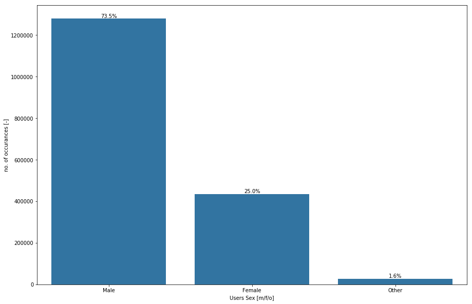

```python
create_ordered_bar_chart(df, 'member_gender', 'no. of occurances [-]', -5000)
plt.xlabel('Users Sex [m/f/o]');
#df['member_gender'].value_counts()
```

> Observation: About 3/4 of all customers are male.

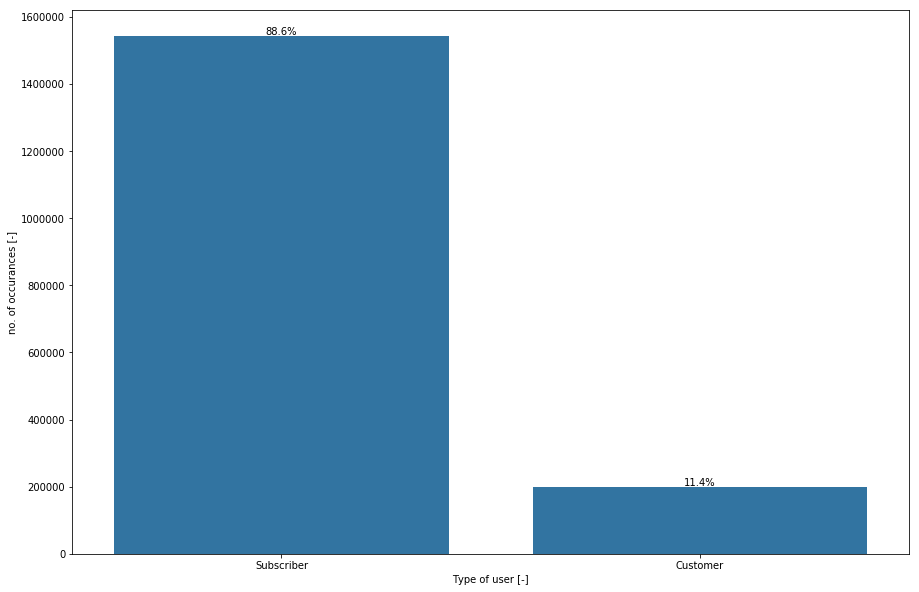

```python
create_ordered_bar_chart(df, 'user_type', 'no. of occurances [-]', -5000)
plt.xlabel('Type of user [-]');
```

> Observation: Almost 90 % of all customers use this service as subsribed regular users while only about 10 % are casual users.

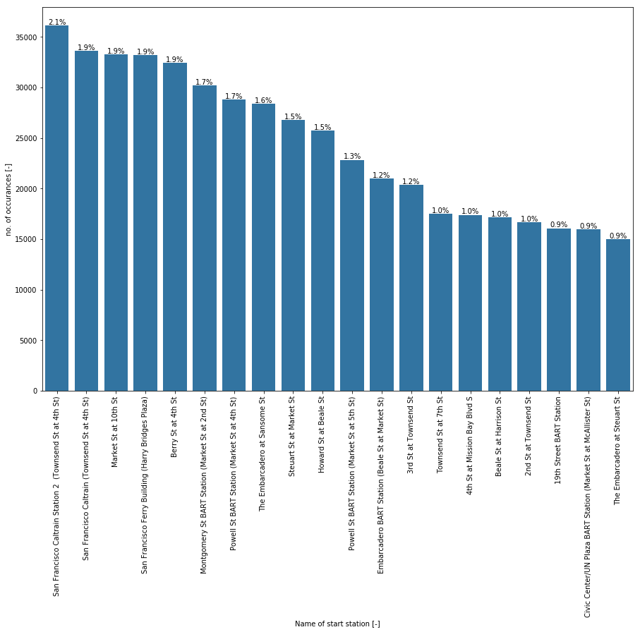

```python
create_ordered_bar_chart(df, 'start_station_name', 'no. of occurances [-]', -100)
plt.xlabel('Name of start station [-]');
plt.xticks(rotation = 90);
```

> Observation: Most rentals start at "SF Caltrain Station 2"

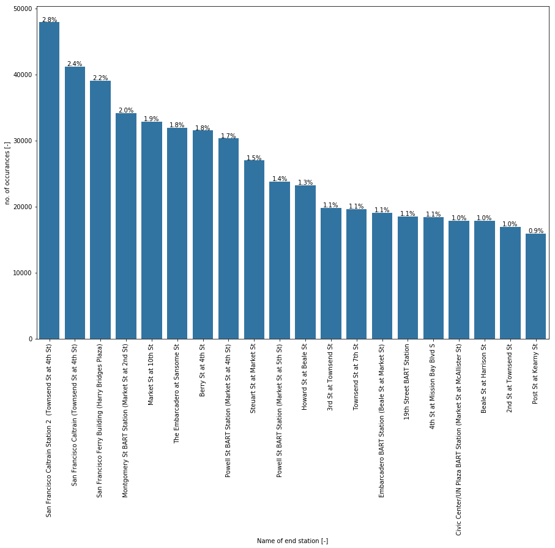

```python
create_ordered_bar_chart(df, 'end_station_name', 'no. of occurances [-]', -100)
plt.xlabel('Name of end station [-]');
plt.xticks(rotation = 90);
```

> Observation: Most rentals end at "SF Caltrain Station 2"

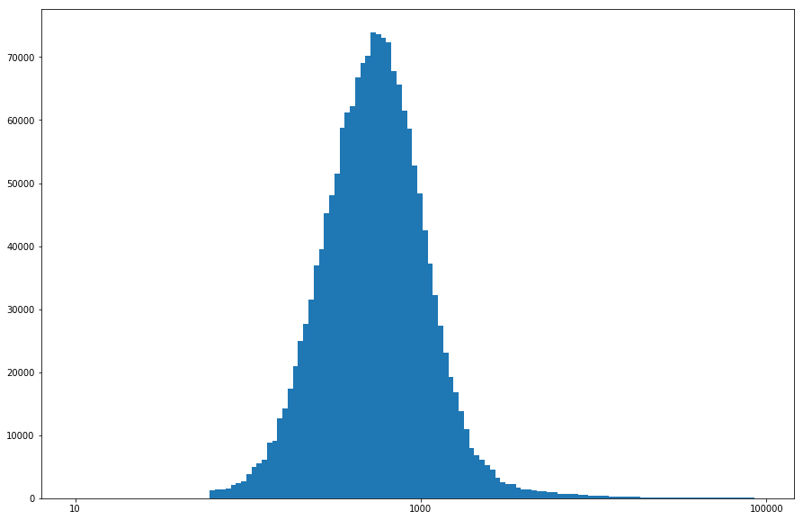

```python
def func_trans(x, inverse = False):
    """ transformation helper function """
    if not inverse:
        return np.log10(x)
    else:
        return np.power(10, x)

bin_width = 0.03;# as defined by func_trans
tick_width = 2;# as defined by func_trans
x_start = 1;# as defined by func_trans
bin_edges = np.arange(x_start, func_trans(df['duration_sec'].max()) + bin_width, bin_width);
plt.hist(df['duration_sec'].apply(func_trans), bins = bin_edges);
tick_locs = np.arange(x_start, func_trans(df['duration_sec'].max()) + tick_width, tick_width);
plt.xticks(tick_locs, func_trans(tick_locs, inverse = True).astype(int));
```

> Observation: The distribution of the rental duration is unimodally distributed in a logarithmic representation with its mean at 773 seconds. There are many outliers which are caused by very long rental durations (possible reason: customer didnt return the bike or the system falsly didn't detect the return of the bike).

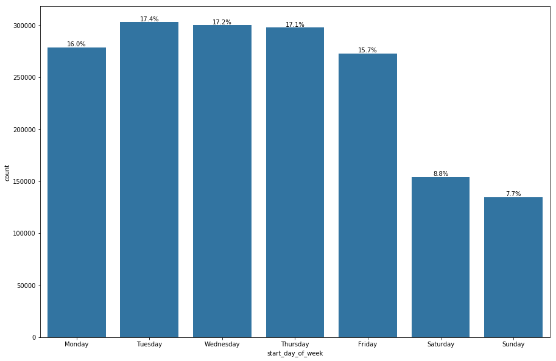

```python
n_points = df.shape[0]
max_count = df['start_day_of_week'].value_counts().max()
max_prop = max_count / n_points

# generate tick mark locations and names
tick_props = np.arange(0, max_prop, 0.05)
tick_names = ['{:0.2f}'.format(v) for v in tick_props]

# create the plot
base_color = sb.color_palette()[0]
sb.countplot(data = df, x = 'start_day_of_week', color = base_color, order = ['Monday', 'Tuesday', 'Wednesday', 'Thursday' ,'Friday', 'Saturday', 'Sunday'])

var_counts = df['start_day_of_week'].value_counts()
locs, labels = plt.xticks() # get the current tick locations and labels

# loop through each pair of locations and labels
for loc, label in zip(locs, labels):

    # get the text property for the label to get the correct count
    count = var_counts[label.get_text()]
    pct_string = '{:0.1f}%'.format(100 * count / n_points)

    # print the annotation just below the top of the bar
    plt.text(loc, count + 1000, pct_string, ha = 'center', color = 'black')
```

> Observation: Most rentals take place on working days with its maximum on mid-week (Tuesday, Wednesday, Thursday). On the weekends the rental frequency drops by around 50%.

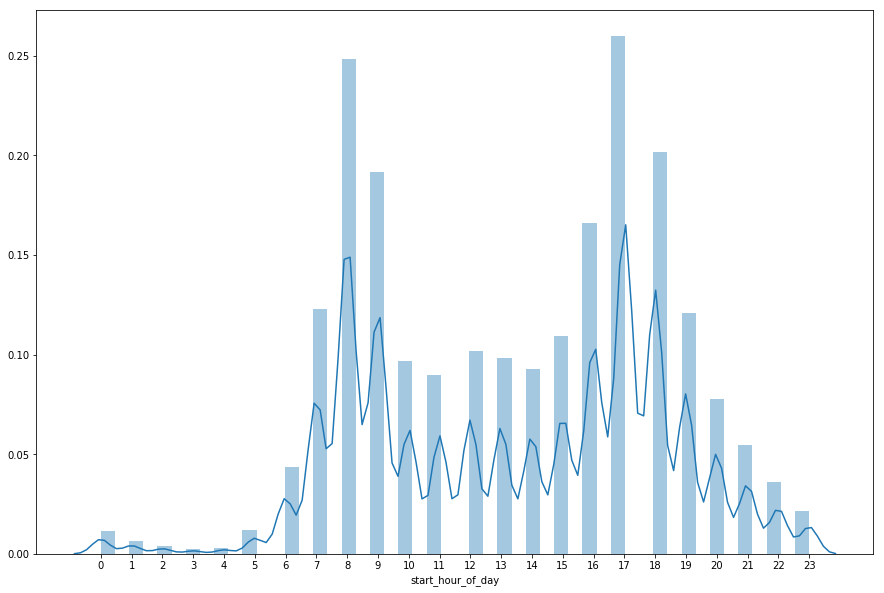

```python
sb.distplot(df['start_hour_of_day']);
plt.xticks(np.arange(0,24,1),np.arange(0,24,1));
```

> Observation: Most rentals start at 08:00h (start of work) and 17:00h (end of work). It could be interesting to further observe the hour of bike return and correlatte the rental duration in this matter.

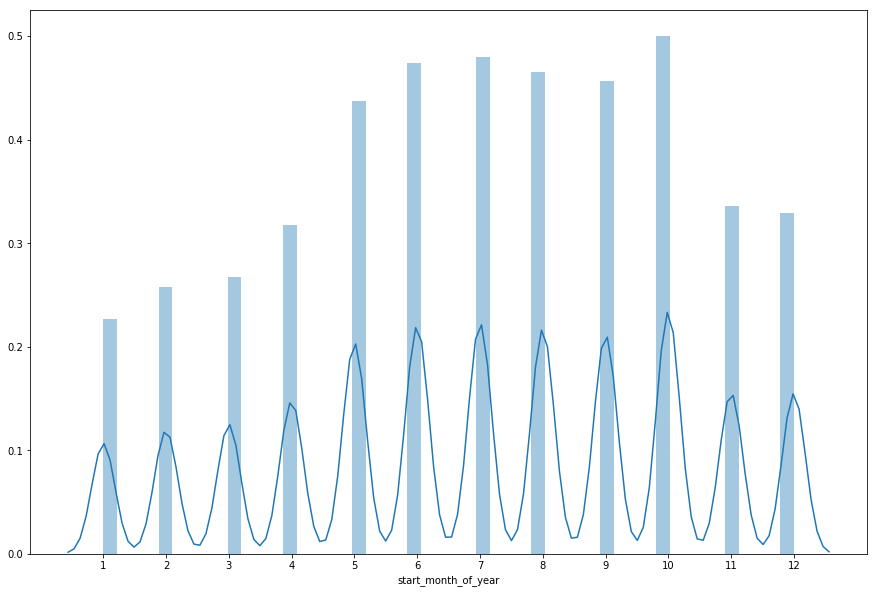

```python
sb.distplot(df['start_month_of_year']);
plt.xticks(np.arange(1,13,1),np.arange(1,13,1));
```

> Observation: Most rentals take place in and around the sommer time.

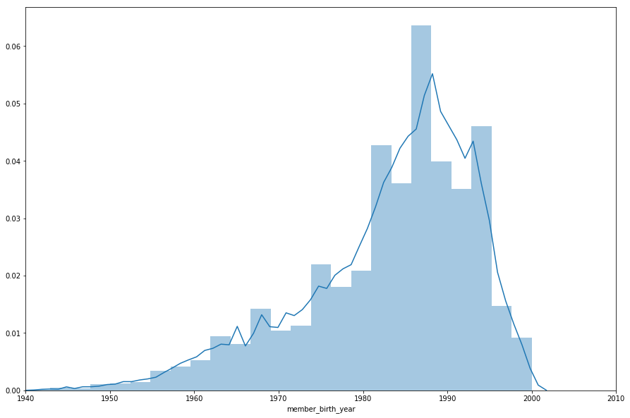

```python
sb.distplot(df['member_birth_year']);
plt.xlim([1940, 2010]);
#plt.xscale('log')
```

> Observation: The customers mean age is 1983. The age distribution is left skewed.

## Bivariate Exploration

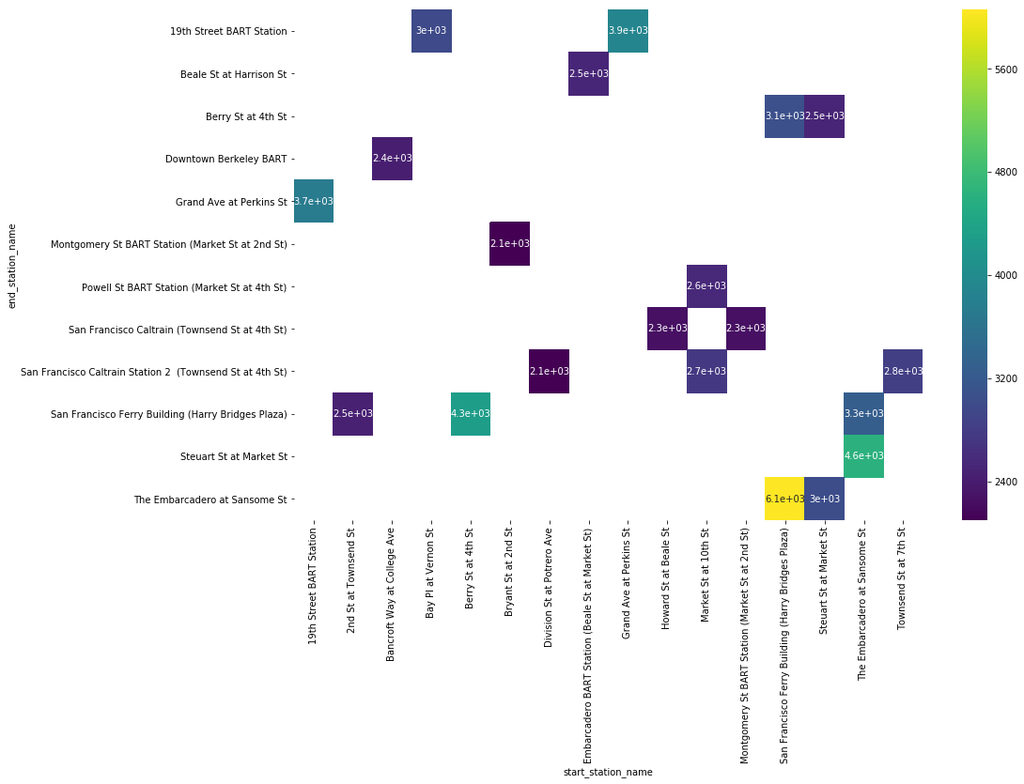

```python
# preconditioning
#print(df['start_station_name'].nunique())
#print(df['end_station_name'].nunique())

filtered = df.groupby(['start_station_name', 'end_station_name']).filter(lambda x: len(x) >= 2100)

ct_counts = filtered.groupby(['start_station_name', 'end_station_name']).size()
ct_counts = ct_counts.reset_index(name = 'count')
ct_counts = ct_counts.pivot(index = 'end_station_name', columns = 'start_station_name', values = 'count')

#plotting
sb.heatmap(ct_counts, annot = True, cmap = 'viridis', vmin = 2100);
```

It would be interesting to identify the most popular routes for the customers. Since there are over 300 rental locations, we have to reduce the amount of observed locations. A filter is used to drop all routes or connections that have less then 2100 occurances. All other locations are plotted in a heatmap.

> Observations: The most driven route starts at "SF Ferry Building" and ends at "The Embarcadero". We can assume that this route brings commuters from the ferry harbour to the next public transportation hub. Another observation is, that the Matrix is not symmetric. That means that end and start locations are not interchangeble. This means that customers dont always use the same route for their return trip.

```python
#bin_width = 30
#bin_edges = np.arange(0, df['duration_sec'].max() + bin_width, bin_width)
#g = sb.FacetGrid(data = df, hue = 'start_day_of_week', height = 15)
#g.map(freq_poly, "duration_sec", bins = bin_edges)
#g.add_legend()
#g.set(xlim = [50, 2000])
#g.set(ylim = [0, 14000])
#plt.xscale('log')
```

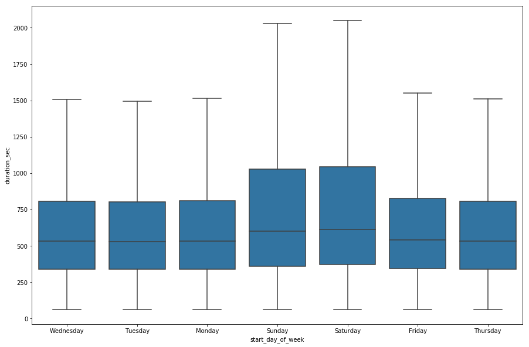

```python
base_color = sb.color_palette()[0];
sb.boxplot(data = df, x = 'start_day_of_week', y = 'duration_sec', color = base_color, showfliers=False);
#plt.xticks(rotation = 15);
```

> Observations: The mean rental duration increases over the weekend. This might indicate that customers use this service primarely to commute on work days, while on weekend days more leisure rides might be planned.

```python
#bin_width = 30
#bin_edges = np.arange(0, df['duration_sec'].max() + bin_width, bin_width)
#g = sb.FacetGrid(data = df, hue = 'member_gender', size = 15)
#g.map(freq_poly, "duration_sec", bins = bin_edges)
#g.add_legend()
#g.set(xlim = [50, 2000])
#g.set(ylim = [0, 60000])
#plt.xscale('log')
```

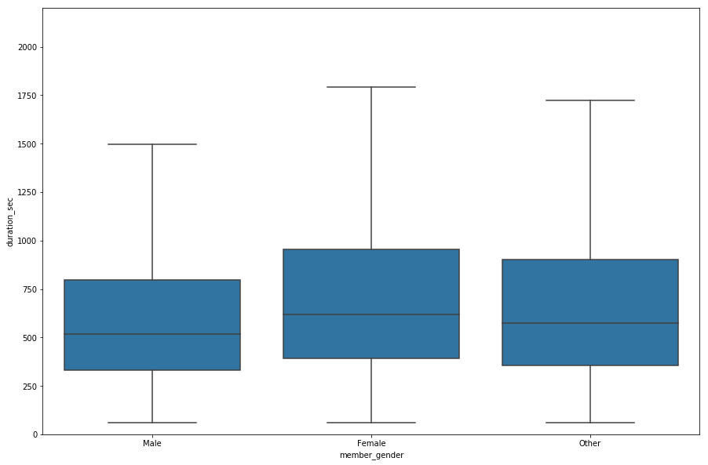

```python
base_color = sb.color_palette()[0];
sb.boxplot(data = df, x = 'member_gender', y = 'duration_sec', color = base_color, showfliers=False);
#plt.xticks(rotation = 15);
plt.ylim ([0, 2200]);
```

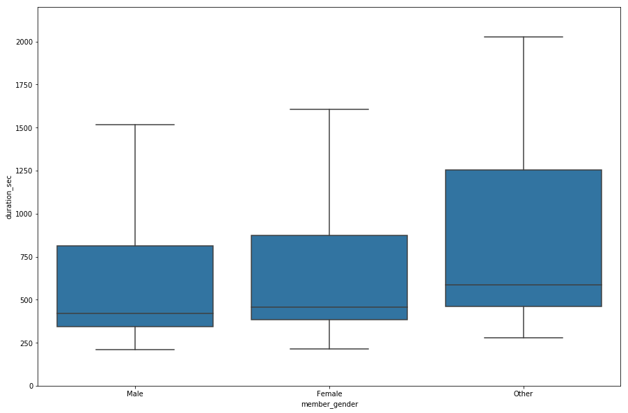

```python
df_new = df.copy()
df_new = df_new[(df_new['start_station_name'] == 'San Francisco Ferry Building (Harry Bridges Plaza)') & (df_new['end_station_name'] == 'The Embarcadero at Sansome St')]
#df_new.head()
base_color = sb.color_palette()[0];
sb.boxplot(data = df_new, x = 'member_gender', y = 'duration_sec', color = base_color, showfliers=False);
#plt.xticks(rotation = 15);
plt.ylim ([0, 2200]);
```

> Observations: When looking at the mean duration of rental, female customers seems to take a little bit more time. If we focus on the most used commuter route, this difference appear to shrink.

```python
#bin_width = 30
#bin_edges = np.arange(0, df['duration_sec'].max() + bin_width, bin_width)
#g = sb.FacetGrid(data = df, hue = 'start_hour_of_day', size = 15, palette = 'viridis')
#g.map(freq_poly, "duration_sec", bins = bin_edges)
#g.add_legend()
#g.set(xlim = [50, 2000])
#g.set(ylim = [0, 10000])
#plt.xscale('log')
```

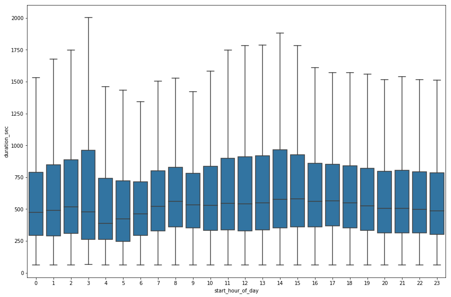

```python
base_color = sb.color_palette()[0];
sb.boxplot(data = df, x = 'start_hour_of_day', y = 'duration_sec', color = base_color, showfliers=False);
#plt.xticks(rotation = 15);
```

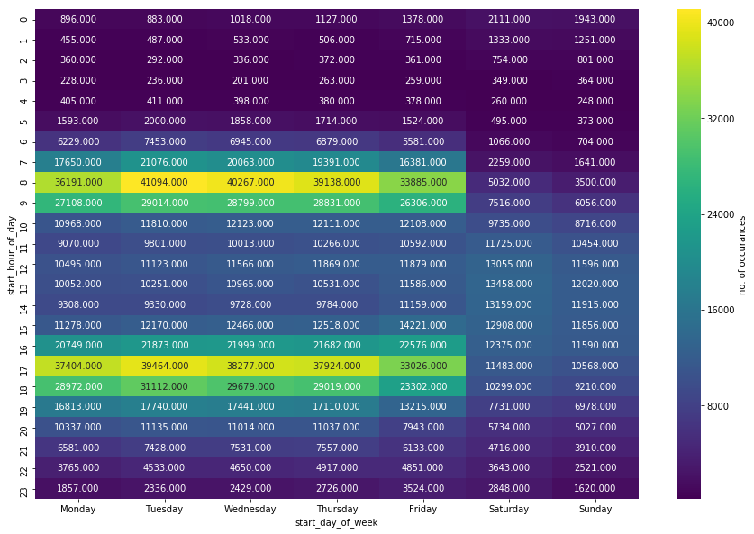

```python
cat_means = df.groupby(['start_day_of_week', 'start_hour_of_day']).count()['duration_sec'];
cat_means = cat_means.reset_index(name = 'num_var2_avg');
cat_means['start_day_of_week'] = pd.Categorical(cat_means['start_day_of_week'], categories =
    ['Monday','Tuesday','Wednesday','Thursday','Friday','Saturday', 'Sunday'],
    ordered=True)
cat_means = cat_means.pivot(index = 'start_hour_of_day', columns = 'start_day_of_week',
                            values = 'num_var2_avg');
sb.heatmap(cat_means, annot = True, fmt = '.3f',
           cbar_kws = {'label' : 'no. of occurances'}, cmap = 'viridis');
```

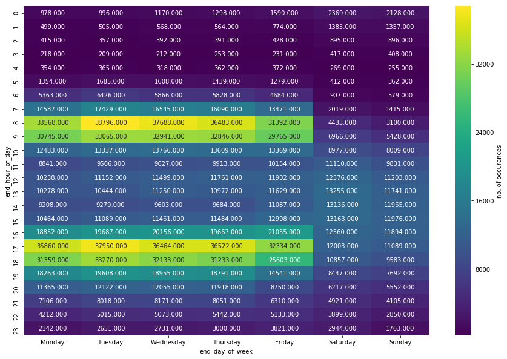

```python
cat_means = df.groupby(['end_day_of_week', 'end_hour_of_day']).count()['duration_sec'];
cat_means = cat_means.reset_index(name = 'num_var2_avg');
cat_means['end_day_of_week'] = pd.Categorical(cat_means['end_day_of_week'], categories =
    ['Monday','Tuesday','Wednesday','Thursday','Friday','Saturday', 'Sunday'],
    ordered=True)
cat_means = cat_means.pivot(index = 'end_hour_of_day', columns = 'end_day_of_week',
                            values = 'num_var2_avg');
sb.heatmap(cat_means, annot = True, fmt = '.3f',
           cbar_kws = {'label' : 'no. of occurances'}, cmap = 'viridis');
```

> Observations: We can observe that most rental actions around start of work and end of work (on weekends the most rentals). This leaves 3 different scenarios:
> - customers rent bikes for the intervalls in between these hours
> - customers rent bikes for 24 hours
> - customers only rent their bikes for very short amounts of time (less than 1 hour)

> This should be assessed within future multivariate exploration.

```python
#bin_width = 30
#bin_edges = np.arange(0, df['duration_sec'].max() + bin_width, bin_width)
#g = sb.FacetGrid(data = df, hue = 'user_type', size = 15, palette = 'viridis')
#g.map(freq_poly, "duration_sec", bins = bin_edges)
#g.add_legend()
#g.set(xlim = [50, 2000])
#g.set(ylim = [0, 70000])
#plt.xscale('log')
```

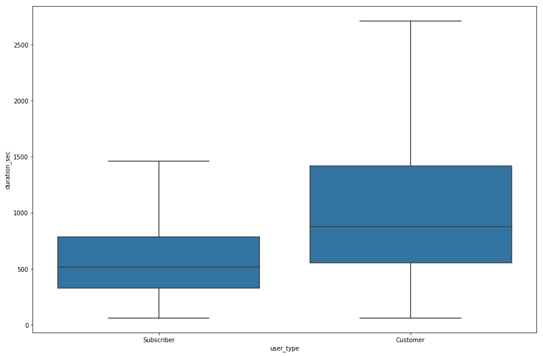

```python
base_color = sb.color_palette()[0];
sb.boxplot(data = df, x = 'user_type', y = 'duration_sec', color = base_color, showfliers=False);
#plt.xticks(rotation = 15);
```

> Observations: Frequent customers use their rental bikes for a shorter amount of time than casual customers.

## Multivariate Exploration

```python
#cat_means = df.groupby(['user_type', 'member_gender']).mean()['duration_sec'];
#cat_means = cat_means.reset_index(name = 'num_var2_avg');
#cat_means = cat_means.pivot(index = 'member_gender', columns = 'user_type',
#                            values = 'num_var2_avg');
#sb.heatmap(cat_means, annot = True, fmt = '.3f',
#           cbar_kws = {'label' : 'mean(duration_sec)'}, cmap = 'viridis');
```

```python
#cat_means = df.groupby(['user_type', 'start_day_of_week']).mean()['duration_sec'];
#cat_means = cat_means.reset_index(name = 'num_var2_avg');
#cat_means['start_day_of_week'] = pd.Categorical(cat_means['start_day_of_week'], categories =
#    ['Monday','Tuesday','Wednesday','Thursday','Friday','Saturday', 'Sunday'],
#    ordered=True)
#cat_means = cat_means.pivot(index = 'start_day_of_week', columns = 'user_type',
#                            values = 'num_var2_avg');
#sb.heatmap(cat_means, annot = True, fmt = '.3f',
#           cbar_kws = {'label' : 'mean(duration_sec)'}, cmap = 'viridis');
```

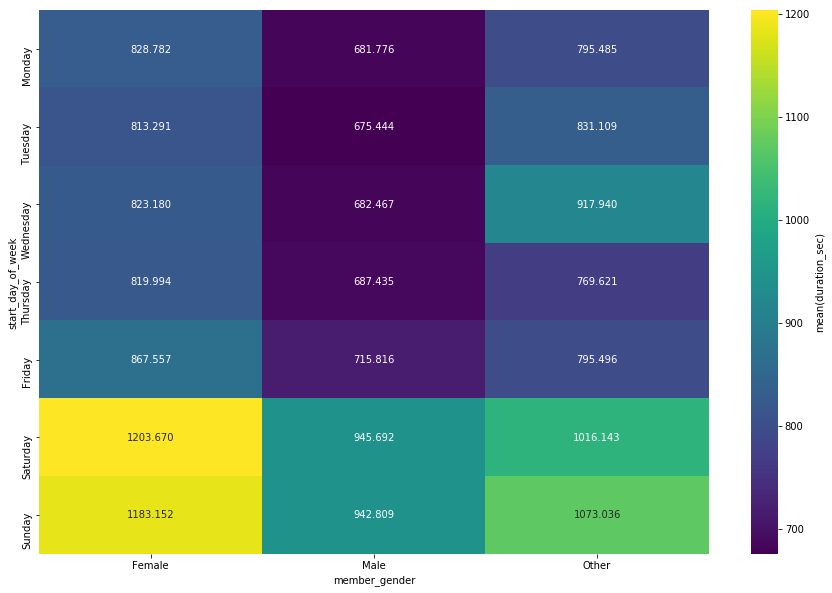

```python
cat_means = df.groupby(['member_gender', 'start_day_of_week']).mean()['duration_sec'];
cat_means = cat_means.reset_index(name = 'num_var2_avg');
cat_means['start_day_of_week'] = pd.Categorical(cat_means['start_day_of_week'], categories =
    ['Monday','Tuesday','Wednesday','Thursday','Friday','Saturday', 'Sunday'],
    ordered=True)
cat_means = cat_means.pivot(index = 'start_day_of_week', columns = 'member_gender',
                            values = 'num_var2_avg');
sb.heatmap(cat_means, annot = True, fmt = '.3f',
           cbar_kws = {'label' : 'mean(duration_sec)'}, cmap = 'viridis');
```

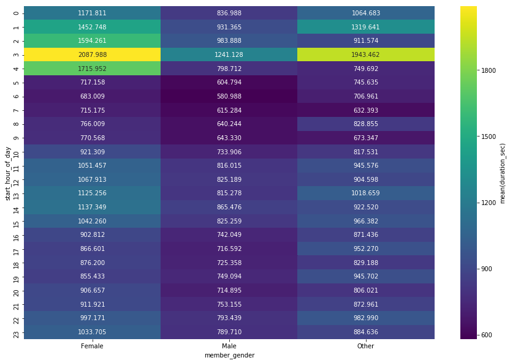

```python
cat_means = df.groupby(['member_gender', 'start_hour_of_day']).mean()['duration_sec'];
cat_means = cat_means.reset_index(name = 'num_var2_avg');
cat_means = cat_means.pivot(index = 'start_hour_of_day', columns = 'member_gender',
                            values = 'num_var2_avg');
sb.heatmap(cat_means, annot = True, fmt = '.3f',
           cbar_kws = {'label' : 'mean(duration_sec)'}, cmap = 'viridis');
```

> Observations: customers who rent their bike at 03:00h in the morning will keep their bikes longer then others (party returners who keep the bike overnight?).

```python
#cat_means = df.groupby(['user_type', 'start_hour_of_day']).mean()['duration_sec'];
#cat_means = cat_means.reset_index(name = 'num_var2_avg');
#cat_means = cat_means.pivot(index = 'start_hour_of_day', columns = 'user_type',
#                            values = 'num_var2_avg');
#sb.heatmap(cat_means, annot = True, fmt = '.3f',
#           cbar_kws = {'label' : 'mean(duration_sec)'}, cmap = 'viridis');
```